# Lab 7: Classification and Regression Trees

Ziping Xu

2/21/2020

## Classification Tree

We look at the spam email classification problem in today’s lab. The dataset is accessible at https://archive.ics.uci.edu/ml/datasets/spambase. There are 57 attributes with 48 continuous real [0,100] attributes of type `word_freq_WORD` representing percentage of words in the e-mail that match WORD and 6 continuous real [0,100] attributes of type char_freq_CHAR for percentage of characters matching CHAR. The attributes on captical words and punctuations are also included.

```r
set.seed(1)
dat = read.csv("spambase.data", header = F)

# loading the names
names = read.table("names.txt")[, 1]
colnames(dat) = names
dat$spam = factor(dat$spam)
levels(dat$spam) = c("Non-Spam", "Spam")

# splitting training and testing set
n = dim(dat)[1]; p = 0.7
train_id = sample(seq(1, n ,1), floor(n * p))
train = dat[train_id, ]
test = dat[-train_id, ]
```

Let us take a simple look at the dataset. Usually in a word vector, words appearing too frequently or too rarely can be useless in predicting. We order the first 48 columns accroding to their mean frequency. On average, the words, you and your accounts for more than 2.5% of the total length. We will use tree model to comfirm whether our intuition is correct.

```r
mean_freq = colMeans(train[, 1:48])
mean_freq[order(mean_freq)]
```

```
     word_freq_table      word_freq_parts word_freq_conference         word_freq_cs   word_freq_original
         0.004984472          0.014531056          0.030704969          0.041114907          0.046559006
       word_freq_857        word_freq_415  word_freq_addresses     word_freq_report    word_freq_receive
         0.047319876          0.048416149          0.049335404          0.059984472          0.060285714
    word_freq_telnet     word_freq_direct         word_freq_3d    word_freq_project         word_freq_pm
         0.060937888          0.064543478          0.065602484          0.071183230          0.080760870
    word_freq_credit      word_freq_money       word_freq_data word_freq_technology      word_freq_order
         0.089813665          0.091155280          0.091288820          0.092220497          0.093040373
    word_freq_people        word_freq_lab         word_freq_85       word_freq_over       word_freq_labs
         0.093540373          0.093822981          0.097354037          0.099068323          0.101229814
       word_freq_000       word_freq_make   word_freq_internet     word_freq_remove        word_freq_650
         0.101903727          0.104934783          0.112416149          0.113096273          0.122645963
   word_freq_meeting       word_freq_font       word_freq_1999   word_freq_business        word_freq_edu
         0.123307453          0.126493789          0.140816770          0.147015528          0.179872671
     word_freq_email    word_freq_address       word_freq_mail       word_freq_free        word_freq_hpl
         0.186437888          0.211217391          0.239804348          0.252217391          0.262524845
       word_freq_all         word_freq_re        word_freq_our       word_freq_will         word_freq_hp
         0.278704969          0.302413043          0.306996894          0.532984472          0.535903727
    word_freq_george       word_freq_your        word_freq_you
         0.757111801          0.814307453          1.689021739
```

We further pick some varaibles to verify our intuition. We look at the most frequent word `you` and some ralative rarer varaibles `george` and `report`. We also select `exclamation` and `capital run length` based on our understanding of spam emails.

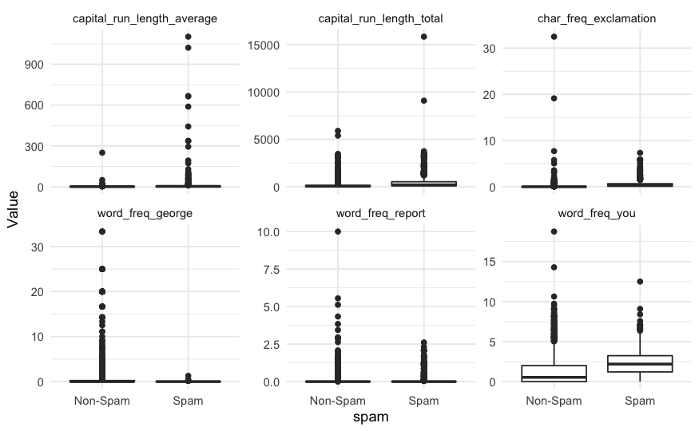

```r
library(ggplot2)
library(dplyr)
library(tidyr)
sel_var = c("word_freq_you", "word_freq_george", "word_freq_report", "char_freq_exclamation", "capital_run_length_average", "capital_run_length_total")
dat.explore = train[, c(sel_var, "spam")]

# Transform from wide table to long table
dat.explore.1 = gather(dat.explore, key = "Variable", value = "Value", -c("spam"))
ggplot(dat.explore.1) + geom_boxplot(aes(x = spam, y = Value)) + facet_wrap(.~Variable, scales = "free_y") + theme_minimal()
```

We can see that some variables have a skewed distribution, which makes the boxplot uninformative. To make the plot more meaningful, we take `log` for them. For the variables with most values to be 0’s (`report` and `george`), we only look at non-zero values.

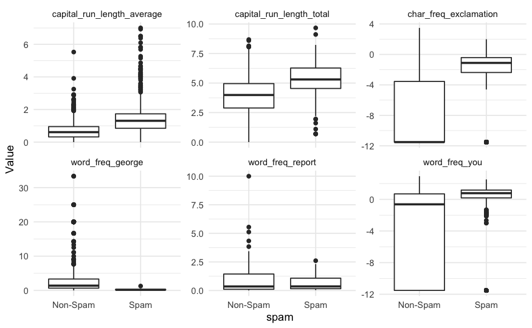

```r
dat.explore.2 = dat.explore
dat.explore.2$capital_run_length_average = log(dat.explore.2$capital_run_length_average)
dat.explore.2$capital_run_length_total = log(dat.explore.2$capital_run_length_total)
dat.explore.2$char_freq_exclamation = log(dat.explore.2$char_freq_exclamation+0.00001)
dat.explore.2$word_freq_you = log(dat.explore.2$word_freq_you+0.00001)
#dat.explore.2$word_freq_george = log(dat.explore.2$word_freq_george+0.00001)

#

dat.explore.2$word_freq_george[dat.explore.2$word_freq_george == 0] = NA
dat.explore.2$word_freq_report[dat.explore.2$word_freq_report == 0] = NA
# dat.explore$word_freq_report = log(dat.explore$word_freq_report+0.00001)

# Transform from wide table to long table
dat.explore.2 = gather(dat.explore.2, key = "Variable", value = "Value", -c("spam"))
ggplot(dat.explore.2) + geom_boxplot(aes(x = spam, y = Value)) + facet_wrap(.~Variable, scales = "free_y") + theme_minimal()
```

We also find the labels are slightly unbalanced, which reminds us to adjust the output label distribution when generalize to a broader application.

```r
table(train$spam)
```

```
Non-Spam     Spam
    1930     1290
```

### Fitting Tree Model

The `rpart` library is used to construct classification and regression trees. We use the function `rpart` in the package to fit the classification tree. Analogous to linear regression, we pass the formula and data. We first try splitting criterion `gini`: $1-\sum_{i=1}^{2}\left(p_{i}\right)^{2}$.

```r
library(rpart)
library(rpart.plot)
library(rattle)
tree1 = rpart(spam ~ ., train, parms = list(split = "gini"), method = "class", cp = 0)
```

One of the most attractive properties of trees is that they can be graphically displayed. We use the `plot()` function to display the tree structure, and the `text()` function to display the node labels. The argument `pretty=0` instructs R to include the category names for any qualitative predictors, rather than simply displaying a letter for each category.

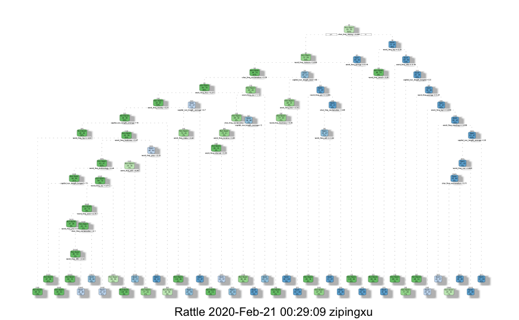

```r
fancyRpartPlot(tree1)
```

Since we didn’t penalize the size of the tree, we generated a extremely complex model. The length (or depth) of each branch is proportional to the reduction in impurity (or quality of split) of that corresponding split. There is a very long branch in our complex model. As mentioned in the lecture, we prune a tree by finding a sub-tree $T$ that minimizes:
$$C(T)=\sum_{t=1}^{|T|} N_{t} \cdot \text{Impurity} (t)+c_{p} \cdot|T|.$$
The tuning parameter $c_p$ can be selected with cross validation. We don’t need to call external functions for cross validation as `rpart` will do 10 fold cross validation when `cp` is not specified.

When calling `rpart` without specifying `cp`, the miss-classification loss (risk) for each sub-tree is calculated by comparing the class predicted for the validation fold vs. actual class; and this risk value for each sub-tree is summed up for all folds. And the function will return a model with the lowest risk. `plotcp` will plot the relative cross-validation error for each sub-tree from smallest to largest.

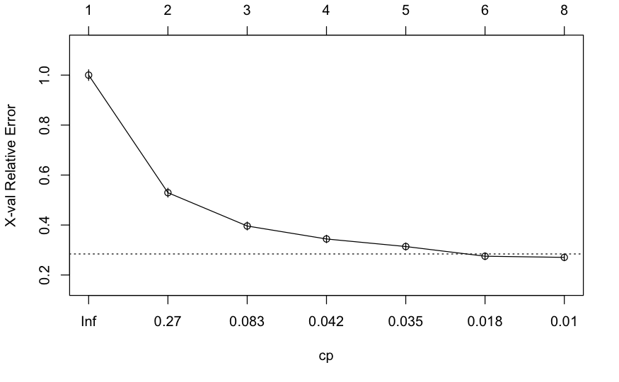

```r
tree.gini = rpart(spam ~ ., data = train, parms = list(split = "gini"), method = "class")
plotcp(tree.gini)
```

As shown in the plot, `cp` for 0.018 and 0.01 have the similar performances. We select the simpler model for `cp = 0.018` and refit the model.

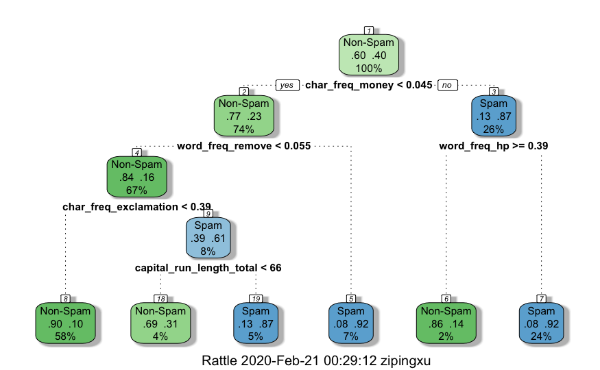

```r
tree.gini = rpart(spam ~ ., train, parms = list(split = "gini"), method = "class", cp = 0.018)
#plot(tree.gini)
#text(tree.gini, pretty = 0)
fancyRpartPlot(tree.gini)
```

```r
set.seed(2)
train.pred=predict(tree.gini, train, type="class")
table(train.pred, train$spam)
```

```
train.pred Non-Spam Spam
  Non-Spam     1834  231
  Spam           96 1059
```

```r
sum(train.pred != train$spam) / dim(train)[1]
```

```
[1] 0.1015528
```

```r
test.pred=predict(tree.gini, test, type="class")
table(test.pred, test$spam)
```

```
test.pred  Non-Spam Spam
  Non-Spam      823  107
  Spam           35  416
```

```r
sum(test.pred != test$spam) / dim(test)[1]
```

```
[1] 0.102824
```

### Comparing different splitting criterions

There are multiple choices of splitting measure. We have implemented `Gini` index. We further try information gain (or Entropy): $-\sum_{k=1}^{K} p_{k}(m) \log p_{k}(m)$.

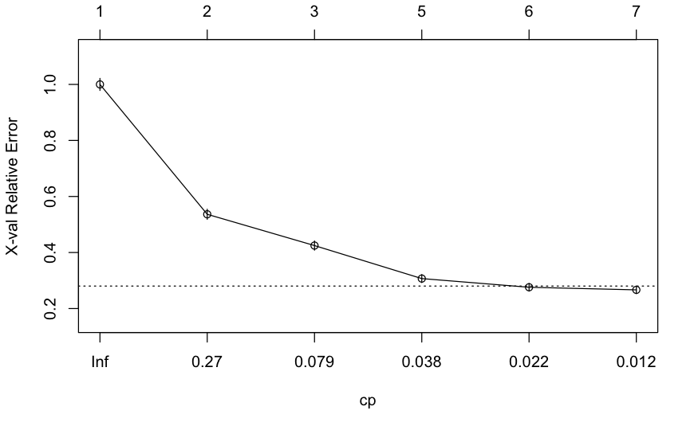

```r
tree.info = rpart(spam ~ ., train, parms = list(split = "information"))
plotcp(tree.info)
```

```r
train.pred=predict(tree.info, train, type="class", cp = 0.012)
table(train.pred, train$spam)
```

```
train.pred Non-Spam Spam
  Non-Spam     1825  199
  Spam          105 1091
```

```r
sum(train.pred != train$spam) / dim(train)[1]
```

```
[1] 0.09440994
```

```r
test.pred=predict(tree.info, test, type="class")
table(test.pred, test$spam)
```

```
test.pred  Non-Spam Spam
  Non-Spam      818   99
  Spam           40  424
```

```r
sum(test.pred != test$spam) / dim(test)[1]
```

```
[1] 0.1006517
```

Using Entropy is slightly better than using Gini index.

### Balancing labels

There are two kinds of misclassification, i.e. misclassify `Spam` as `Non-Spam` and misclassificy `Non-Spam` as `Spam`. From the confusion table in the previous section, the number of two types of errors are unbalanced.

Our model tends to make the error of predicting `Spam` to be `Non-Spam`, since in our training set `Non-Spam` is the dominant class. This can be a problem when we want to control certain type of errors, while in our problem the error of misclassificying `Non-Spam` as `Spam` seems more serious.

We can assign weights to adjust the unbalance to reduce the second error. In our case, since training and testing set have the same label distribution, the true testing error might increase slightly.

```r
prop = table(train$spam) / dim(train)[1]
w = rep(1/prop[2], dim(train)[1])
w[which(train$spam == "Non-Spam")] = 1/prop[1]

tree.balance = rpart(spam ~ ., train, parms = list(split = "information"), weights = w)

train.pred=predict(tree.balance, train, type="class")
table(train.pred, train$spam)
```

```
train.pred Non-Spam Spam
  Non-Spam     1783  177
  Spam          147 1113
```

```r
sum(train.pred != train$spam) / dim(train)[1]
```

```
[1] 0.1006211
```

```r
test.pred=predict(tree.balance, test, type="class")
table(test.pred, test$spam)
```

```
test.pred  Non-Spam Spam
  Non-Spam      796   81
  Spam           62  442
```

```r
sum(test.pred != test$spam) / dim(test)[1]
```

```
[1] 0.1035482
```

The mistakes of predicting `Non-Spam` for a real `Spam` sample are reduced.

## Regression Tree

We will fit a regression tree on the `Boston` housing data. Recall that this data is located in the `MASS` package. In this section, our goal is to predict the variable `medv` from all other variables in the dataset. For the regression tree, we use the Mean Square Error (MSE) as the impurity measure to split.

```r
library(MASS)
set.seed(1)
train = sample(1:nrow(Boston), nrow(Boston)/2)
tree.boston=rpart(medv~.,Boston,subset=train)
```

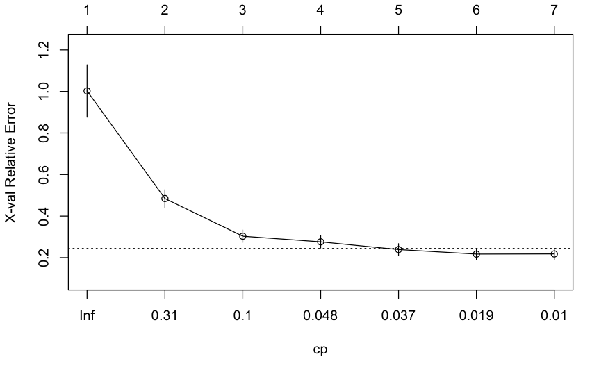

```r
plotcp(tree.boston)
```

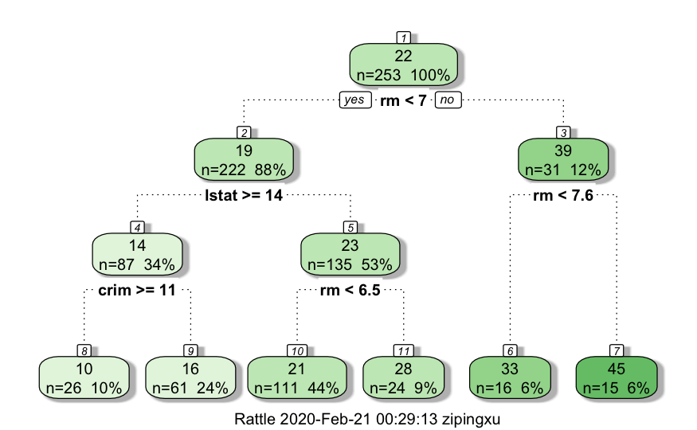

```r
tree.boston=rpart(medv~.,Boston,subset=train, cp = 0.019)
fancyRpartPlot(tree.boston)
```

We test the performance of pruned tree.

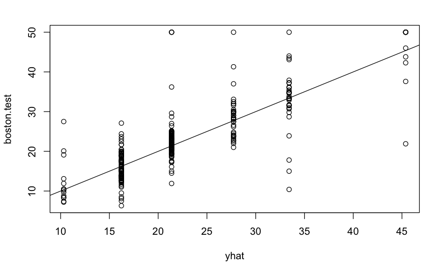

```r
yhat=predict(tree.boston,newdata=Boston[-train,])
boston.test=Boston[-train,"medv"]
plot(yhat,boston.test)
abline(0,1)
```

To calculate test MSE, we can do

```r
mean((yhat-boston.test)^2)
```

```
[1] 35.16439
```

We see that the test MSE associated with the fitted regression tree is 35.16439.

**Question**: What does this MSE imply about the prediction? How do you interpret the test MSE?

The square root of the MSE (i.e. the RMSE) is around 5.93, indicating that this model leads to test predictions that are within around 5930 dollars of the true median home value for the suburb.